# R Notebook

# Individual Responses

To better understand why certain sites express correlations in their N, P, and K response trajectories, we can look at the individual responses of species that constitute these community-level effects.

From existing work on nutrient enrichment (both in NutNet and other meta-analysis), there are a number of patterns that might be expected:

- Dominant species respond more positively to nutrient enrichment than non-dominants
- Certain functional groups (e.g. legumes) are likely to respond to P, K enrichment over others

These relationships may also give us more clues on what sort of site-level covariates might be interested.

In the process of calculating these, I’ve produced a “tuning table” that has a number of features that can also be used to subset the dataset prior to conducting these analyses:

- Pretrt presence / absence and cover
- Total observations over the course of sampling
- Pretrt dominance and control dominance (abundance / total observed cover)

# Plotting relationships

# Conducting PCA

## No filtering

```
## Number of observations = 2220
```

```
## Importance of components:
##                           PC1    PC2    PC3
## Standard deviation     1.3646 0.7666 0.7417
## Proportion of Variance 0.6207 0.1959 0.1834
## Cumulative Proportion  0.6207 0.8166 1.0000
```

```
##             PC1        PC2        PC3
## trt_N 0.5690463 -0.8156742  0.1042205
## trt_K 0.5831968  0.3109742 -0.7504509
## trt_P 0.5797136  0.4878223  0.6526573
```

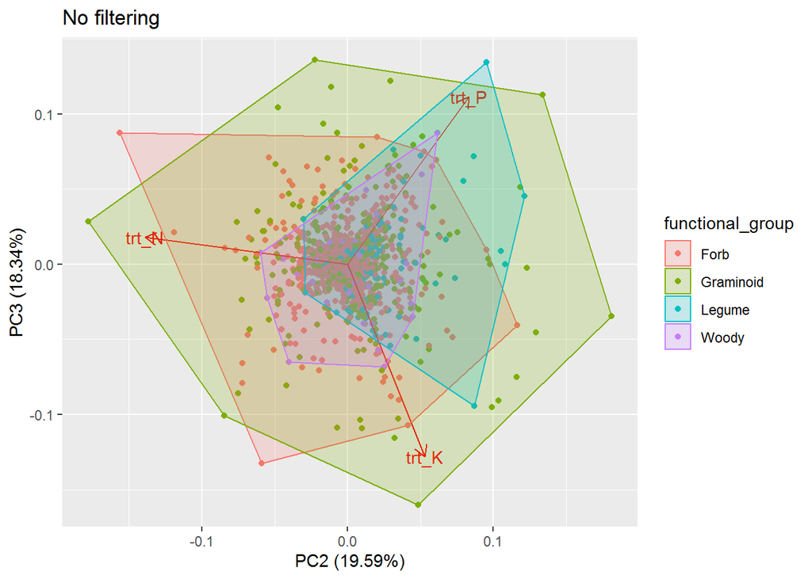

## Filtering by occupancy in control

```
## Number of observations = 640
```

```
## Importance of components:
##                          PC1    PC2    PC3
## Standard deviation     1.361 0.7855 0.7293
## Proportion of Variance 0.617 0.2057 0.1773
## Cumulative Proportion  0.617 0.8227 1.0000
```

```
##             PC1        PC2         PC3
## trt_N 0.5570948 -0.8301143  0.02357142
## trt_K 0.5863706  0.4132992  0.69667299
## trt_P 0.5880603  0.3742913 -0.71700148
```

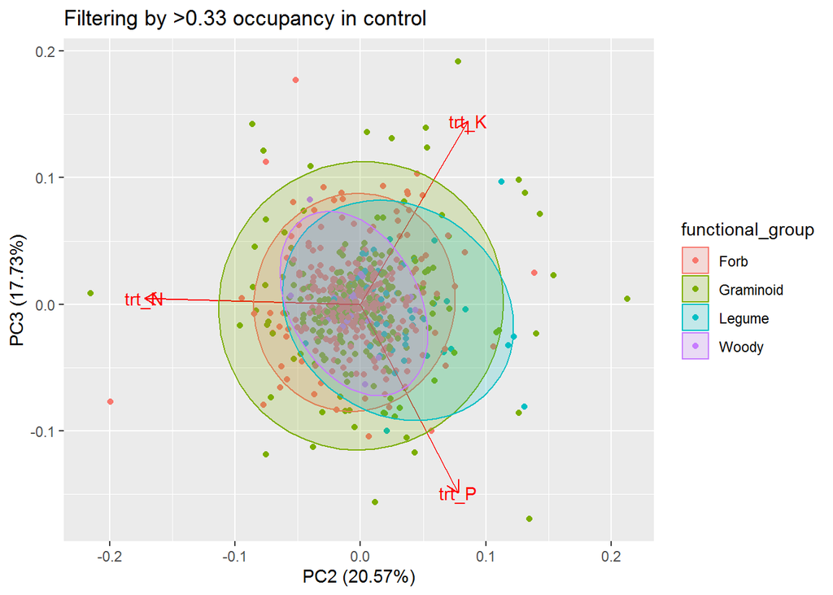

## Filtering by occupancy in all plots

```
## Number of observations = 584
```

```
## Importance of components:
##                           PC1    PC2    PC3
## Standard deviation     1.3642 0.7680 0.7409
## Proportion of Variance 0.6204 0.1966 0.1830
## Cumulative Proportion  0.6204 0.8170 1.0000
```

```
##             PC1        PC2        PC3
## trt_N 0.5692430 -0.7948915  0.2100237
## trt_K 0.5776254  0.5684443  0.5858498
## trt_P 0.5850737  0.2121759 -0.7827325
```

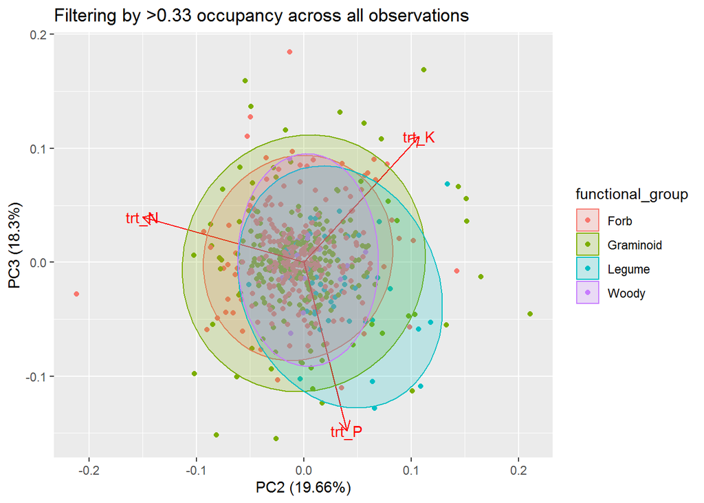

## Filtering by average cover in control

```
## Number of observations = 254
```

```
## Importance of components:
##                           PC1    PC2    PC3
## Standard deviation     1.3112 0.8172 0.7830
## Proportion of Variance 0.5731 0.2226 0.2044
## Cumulative Proportion  0.5731 0.7956 1.0000
```

```
##             PC1        PC2        PC3
## trt_N 0.5645342 -0.7933091  0.2279514
## trt_K 0.5773729  0.5768921  0.5777854
## trt_P 0.5898658  0.1945667 -0.7837105
```

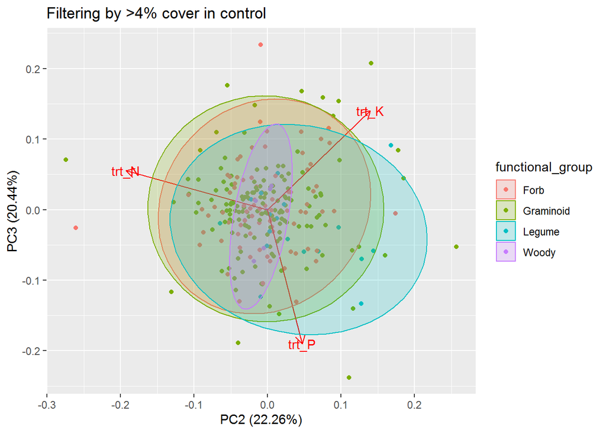

## Filtering by average cover in all plots

```
## Number of observations = 272
```

```
## Importance of components:
##                           PC1    PC2    PC3
## Standard deviation     1.3239 0.7971 0.7823
## Proportion of Variance 0.5842 0.2118 0.2040
## Cumulative Proportion  0.5842 0.7960 1.0000
```

```
##             PC1        PC2        PC3
## trt_N 0.5774477 -0.5725627  0.5820018
## trt_K 0.5721128  0.7923412  0.2118547
## trt_P 0.5824441 -0.2106356 -0.7851061
```

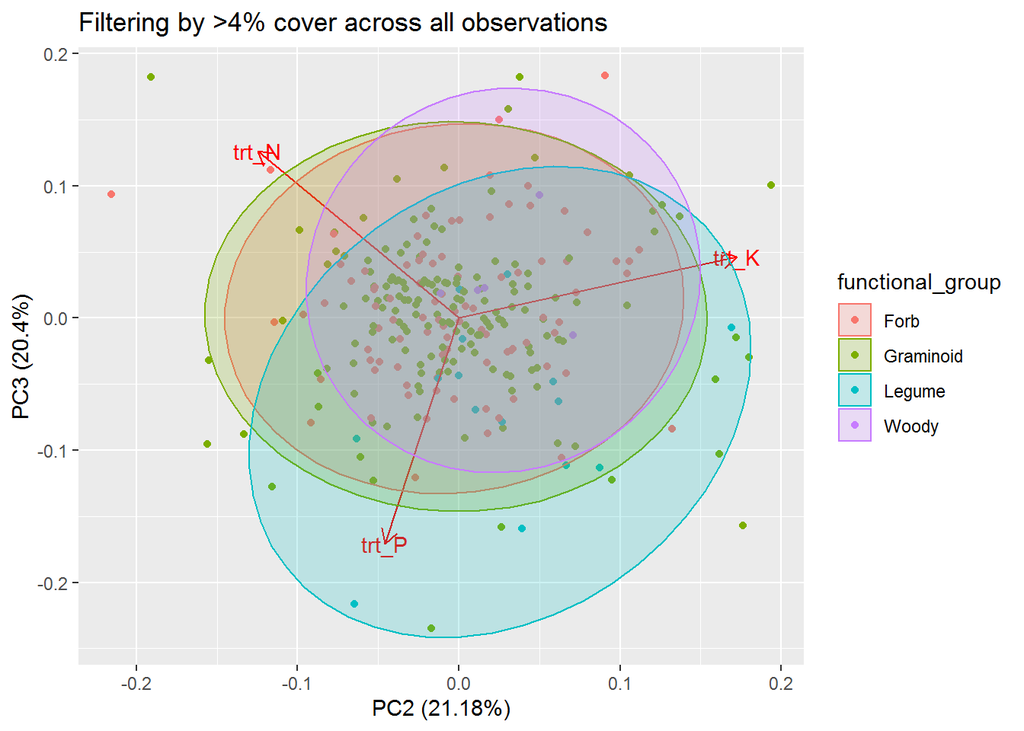

## Filtering by presence in all treatments

```
## Number of observations = 1128
```

```
## Importance of components:
##                           PC1    PC2    PC3
## Standard deviation     1.3681 0.7610 0.7411
## Proportion of Variance 0.6239 0.1930 0.1831
## Cumulative Proportion  0.6239 0.8169 1.0000
```

```
##             PC1        PC2         PC3
## trt_N 0.5706518 -0.8208062  0.02517534
## trt_K 0.5803339  0.4247786  0.69482056
## trt_P 0.5810070  0.3818905 -0.71874236
```

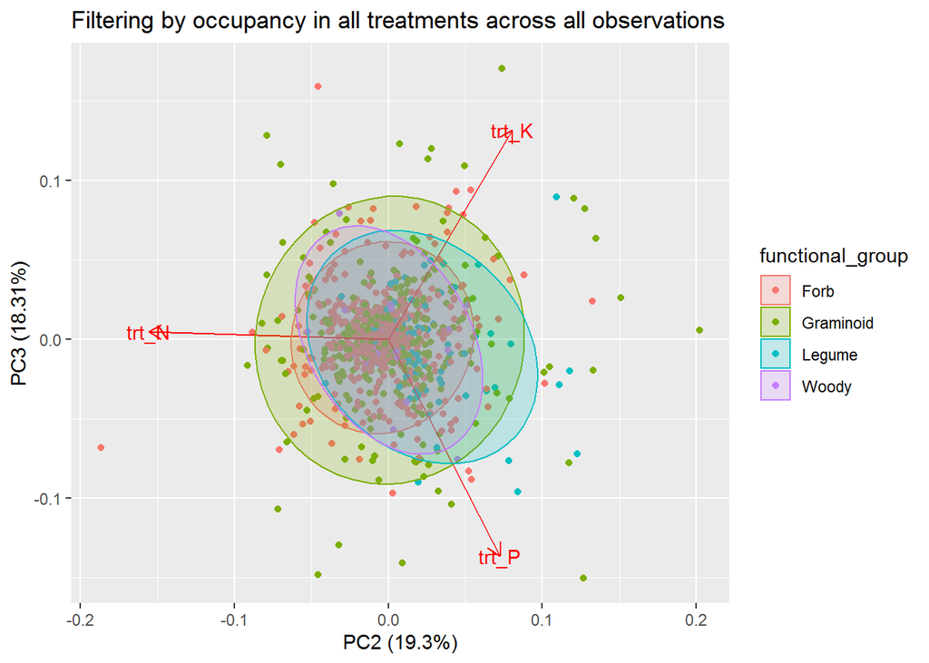